# Assigment 2

Alícia Chimeno Sarabia and Bruna

2023-12-02

# Libraries

```r
library(skimr)
library(car)
library(FactoMineR)
library(dplyr)
```

# Load dataset

```r
#setwd("/Users/ali/Desktop/MASTER/SIM/proj2")
setwd("C:/Users/Brunil/Desktop/Bruna/Master/SIM/assignment_2")
df<-read.csv("customer.xls", sep=",")
```

# Data context

# Data exploration

```r
dim(df)
```

```
## [1] 7043   21
```

```r
names(df)
```

```
##  [1] "customerID"       "gender"           "SeniorCitizen"    "Partner"
##  [5] "Dependents"       "tenure"           "PhoneService"     "MultipleLines"
##  [9] "InternetService"  "OnlineSecurity"   "OnlineBackup"     "DeviceProtection"
## [13] "TechSupport"      "StreamingTV"      "StreamingMovies"  "Contract"
## [17] "PaperlessBilling" "PaymentMethod"    "MonthlyCharges"   "TotalCharges"
## [21] "Churn"
```

```r
str(df)
```

```
## 'data.frame':    7043 obs. of  21 variables:
##  $ customerID      : chr  "7590-VHVEG" "5575-GNVDE" "3668-QPYBK" "7795-CFOCW" ...
##  $ gender          : chr  "Female" "Male" "Male" "Male" ...
##  $ SeniorCitizen   : int  0 0 0 0 0 0 0 0 0 0 ...
##  $ Partner         : chr  "Yes" "No" "No" "No" ...
##  $ Dependents      : chr  "No" "No" "No" "No" ...
##  $ tenure          : int  1 34 2 45 2 8 22 10 28 62 ...
##  $ PhoneService    : chr  "No" "Yes" "Yes" "No" ...
##  $ MultipleLines   : chr  "No phone service" "No" "No" "No phone service" ...
##  $ InternetService : chr  "DSL" "DSL" "DSL" "DSL" ...
##  $ OnlineSecurity  : chr  "No" "Yes" "Yes" "Yes" ...
##  $ OnlineBackup    : chr  "Yes" "No" "Yes" "No" ...
##  $ DeviceProtection: chr  "No" "Yes" "No" "Yes" ...
##  $ TechSupport     : chr  "No" "No" "No" "Yes" ...
##  $ StreamingTV     : chr  "No" "No" "No" "No" ...
##  $ StreamingMovies : chr  "No" "No" "No" "No" ...
##  $ Contract        : chr  "Month-to-month" "One year" "Month-to-month" "One year" ...
##  $ PaperlessBilling: chr  "Yes" "No" "Yes" "No" ...
##  $ PaymentMethod   : chr  "Electronic check" "Mailed check" "Mailed check" "Bank transfer (automatic)" ...
##  $ MonthlyCharges  : num  29.9 57 53.9 42.3 70.7 ...
##  $ TotalCharges    : num  29.9 1889.5 108.2 1840.8 151.7 ...
##  $ Churn           : chr  "No" "No" "Yes" "No" ...
```

```r
#summary(df)
#skim(df)
summary(is.na(df)) #we only have NA values in TotalCharges
```

```
##  customerID        gender        SeniorCitizen    Partner
##  Mode :logical   Mode :logical   Mode :logical   Mode :logical
##  FALSE:7043      FALSE:7043      FALSE:7043      FALSE:7043
##
##  Dependents        tenure        PhoneService    MultipleLines
##  Mode :logical   Mode :logical   Mode :logical   Mode :logical
##  FALSE:7043      FALSE:7043      FALSE:7043      FALSE:7043
##
##  InternetService OnlineSecurity  OnlineBackup    DeviceProtection
##  Mode :logical   Mode :logical   Mode :logical   Mode :logical
##  FALSE:7043      FALSE:7043      FALSE:7043      FALSE:7043
##
##  TechSupport     StreamingTV     StreamingMovies  Contract
##  Mode :logical   Mode :logical   Mode :logical   Mode :logical
##  FALSE:7043      FALSE:7043      FALSE:7043      FALSE:7043
##
##  PaperlessBilling PaymentMethod   MonthlyCharges  TotalCharges
##  Mode :logical    Mode :logical   Mode :logical   Mode :logical
##  FALSE:7043       FALSE:7043      FALSE:7043      FALSE:7032
##                                                   TRUE :11
##    Churn
##  Mode :logical
##  FALSE:7043
##
```

## Variables description

In total, we have 21 variables related to demographic, services, and accountant data. One is the ID, three are numerical variables, and 17 are categorical (? binary) variables. We will conduct a descriptive analysis and a data quality report for each variable, considering aspects such as the number of missing values, errors, and the distribution or balance of the variable… #### 1. customerID

### Demographic data

#### 2. gender

Is a binary variable (female/male).

```r
sum(is.na(df$gender))
```

```
## [1] 0
```

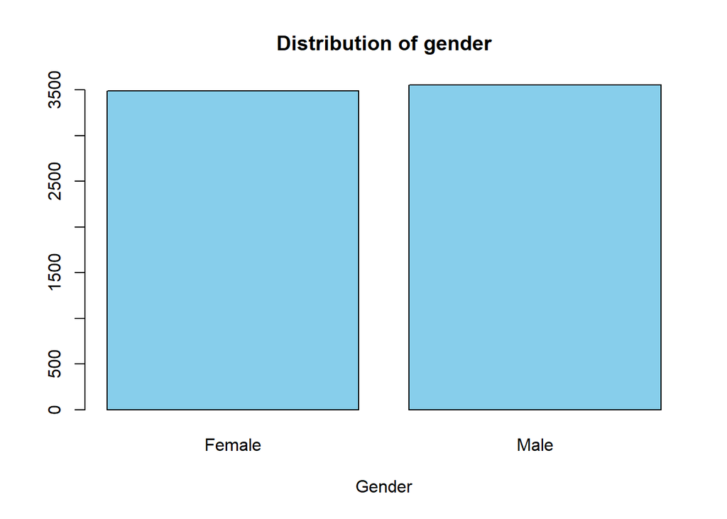

```r
barplot(table(df$gender), main = "Distribution of gender",xlab = "Gender",col = "skyblue")
```

#### 3. SeniorCitizen

It is a binary variable. Levels: 1(=yes)/0(=no).

```r
sum(is.na(df$SeniorCitizen))
```

```
## [1] 0
```

```r
table(df$SeniorCitizen)
```

```
##
##    0    1
## 5901 1142
```

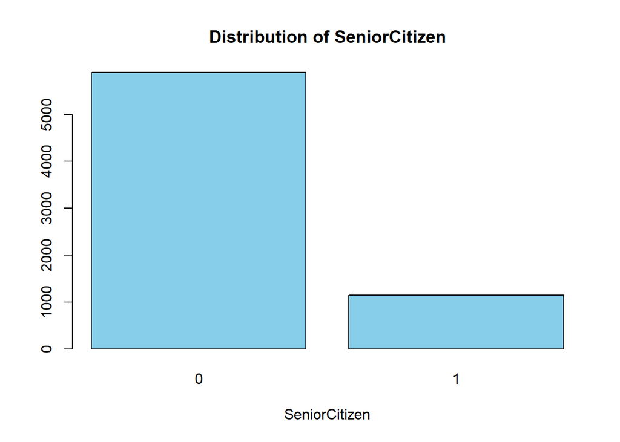

```r
barplot(table(df$SeniorCitizen), main = "Distribution of SeniorCitizen",xlab = "SeniorCitizen",col = "skyblue")
```

#### 4. Partner

It is a binary variable. Levels: Yes/No.

```r
sum(is.na(df$Partner))
```

```
## [1] 0
```

```r
table(df$Partner)
```

```
##
##   No  Yes
## 3641 3402
```

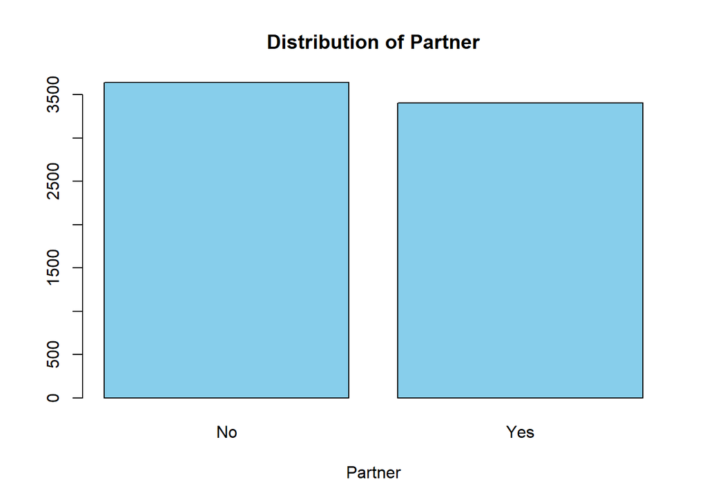

```r
barplot(table(df$Partner), main = "Distribution of Partner",xlab = "Partner",col = "skyblue")
```

#### 5. Dependents

It is a binary variable. Levels: Yes/No.

```r
sum(is.na(df$Dependents))
```

```
## [1] 0
```

```r
table(df$Dependents)
```

```
##
##   No  Yes
## 4933 2110
```

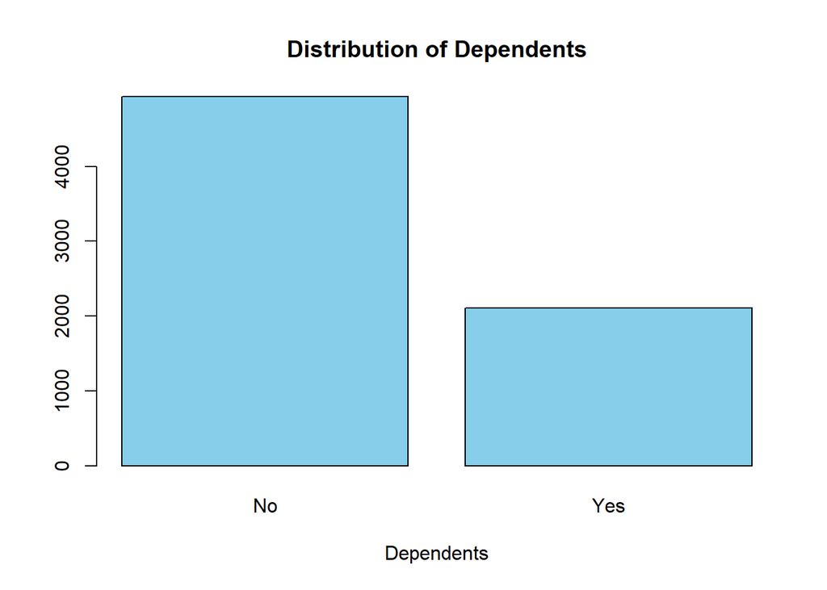

```r
barplot(table(df$Dependents), main = "Distribution of Dependents",xlab = "Dependents",col = "skyblue")
```

### Services of the costumer data

Services that each customer has signed up for : #### 6. tenure It is a numerical variable that indicates the duration, in months, that the customer has stayed with the company.

```r
summary(df$tenure)
```

```
##    Min. 1st Qu.  Median    Mean 3rd Qu.    Max.
##    0.00    9.00   29.00   32.37   55.00   72.00
```

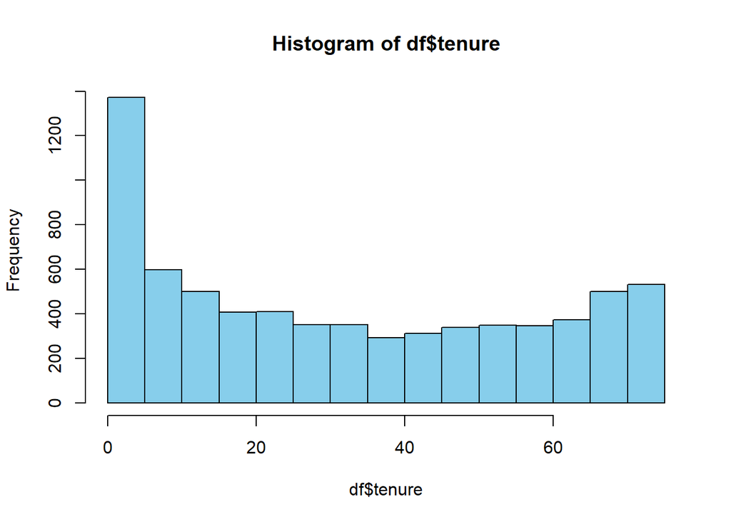

```r
hist(df$tenure,breaks=20, col="skyblue")
```

```r
min(df$tenure)
```

```
## [1] 0
```

Let’s look for the *outliers*.

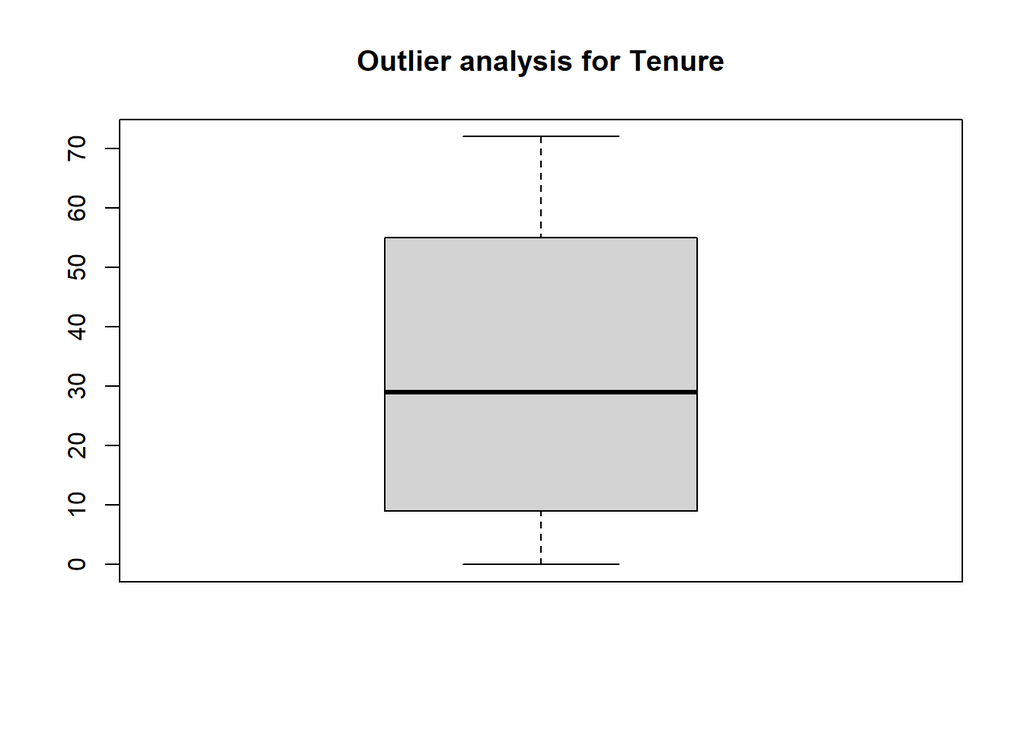

```r
boxplot(df$tenure, main="Outlier analysis for Tenure")
```

```r
sm_t <- summary(df$tenure)
iqr_t <- sm_t["3rd Qu."] - sm_t["1st Qu."]
# Mild Outliers
mild_ub_t <- sm_t["3rd Qu."] + 1.5 * iqr_t
mild_lb_t <- sm_t["1st Qu."] - 1.5 * iqr_t
length(which(df$tenure > mild_ub_t | df$tenure < mild_lb_t)) # number of mild outliers
```

```
## [1] 0
```

```r
# Severe Outliers
severe_ub_t <- sm_t["3rd Qu."] + 3 * iqr_t
severe_lb_t <- sm_t["1st Qu."] - 3 * iqr_t
length(which(df$tenure > severe_ub_t | df$tenure < severe_lb_t)) # number of severe outliers
```

```
## [1] 0
```

There are *no mild nor severe outliers* in Tenure.

#### 7. PhoneService

It is a binary variable. Levels: Yes/No.

```r
sum(is.na(df$PhoneService))
```

```
## [1] 0
```

```r
table(df$PhoneService)
```

```
##
##   No  Yes
##  682 6361
```

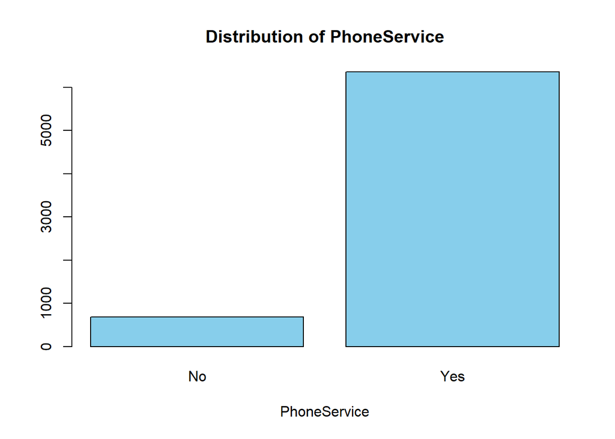

```r
barplot(table(df$PhoneService), main = "Distribution of PhoneService",xlab = "PhoneService",col = "skyblue") #unbalanced
```

#### 8. MultipleLines

Categorical variable with 3 levels, No/No phone service/Yes.

```r
sum(is.na(df$MultipleLines))
```

```
## [1] 0
```

```r
table(df$MultipleLines)
```

```
##
##               No No phone service              Yes
##             3390              682             2971
```

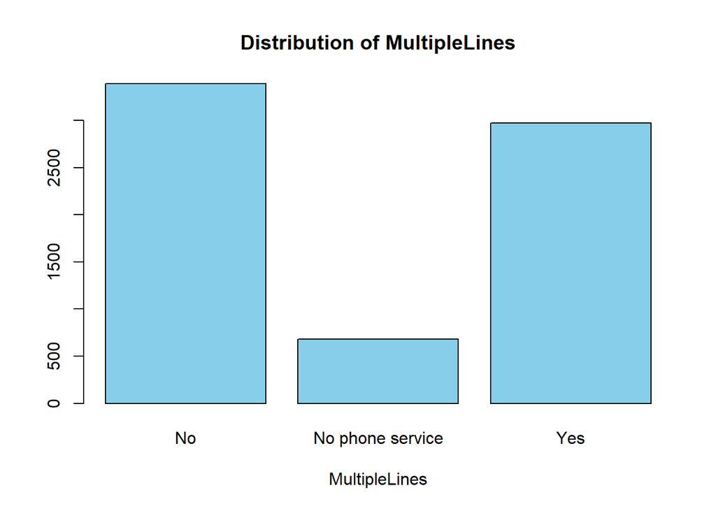

```r
barplot(table(df$MultipleLines), main = "Distribution of MultipleLines",xlab = "MultipleLines",col = "skyblue") #unbalanced
```

Check inconsistencies: - Cannot happen that a costumer has not phoneservice and multiplelines.

```r
subset(df, MultipleLines == "Yes" & PhoneService == "No")
```

```
##  [1] customerID       gender           SeniorCitizen    Partner
##  [5] Dependents       tenure           PhoneService     MultipleLines
##  [9] InternetService  OnlineSecurity   OnlineBackup     DeviceProtection
## [13] TechSupport      StreamingTV      StreamingMovies  Contract
## [17] PaperlessBilling PaymentMethod    MonthlyCharges   TotalCharges
## [21] Churn
## <0 rows> (or 0-length row.names)
```

#### 9. InternetService

Categorical variable with 3 levels: DSL/Fiber optic/No.

```r
table(df$InternetService)
```

```
##
##         DSL Fiber optic          No
##        2421        3096        1526
```

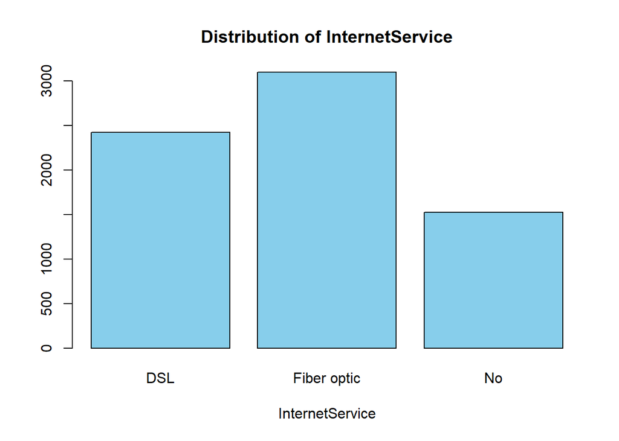

```r
barplot(table(df$InternetService), main = "Distribution of InternetService",xlab = "InternetService",col = "skyblue")
```

#### 10. OnlineSecurity

Categorical variable with 3 levels: No/No internet service/Yes

```r
table(df$OnlineSecurity)
```

```
##
##                  No No internet service                 Yes
##                3498                1526                2019
```

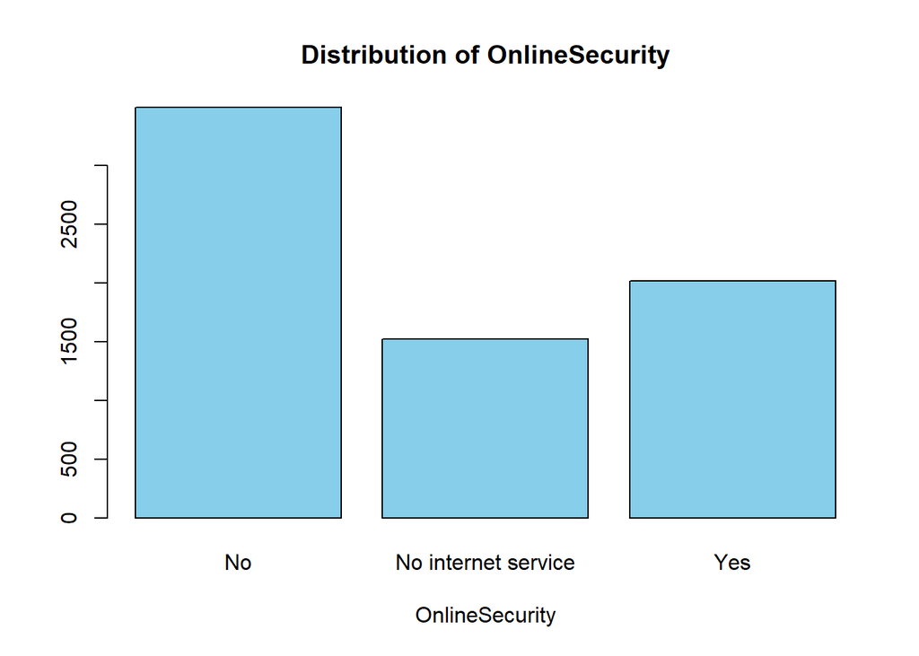

```r
barplot(table(df$OnlineSecurity), main = "Distribution of OnlineSecurity",xlab = "OnlineSecurity",col = "skyblue")
```

# Check concistency

```r
sum(df$InternetService == "No")
```

```
## [1] 1526
```

```r
sum(df$OnlineSecurity == "No internet service")
```

```
## [1] 1526
```

```r
nrow(subset(df, InternetService == "No" & OnlineSecurity == "No internet service"))
```

```
## [1] 1526
```

#### 11. OnlineBackup

Categorical variable with 3 levels: No/No internet service/Yes

```r
table(df$OnlineBackup)
```

```
##
##                  No No internet service                 Yes
##                3088                1526                2429
```

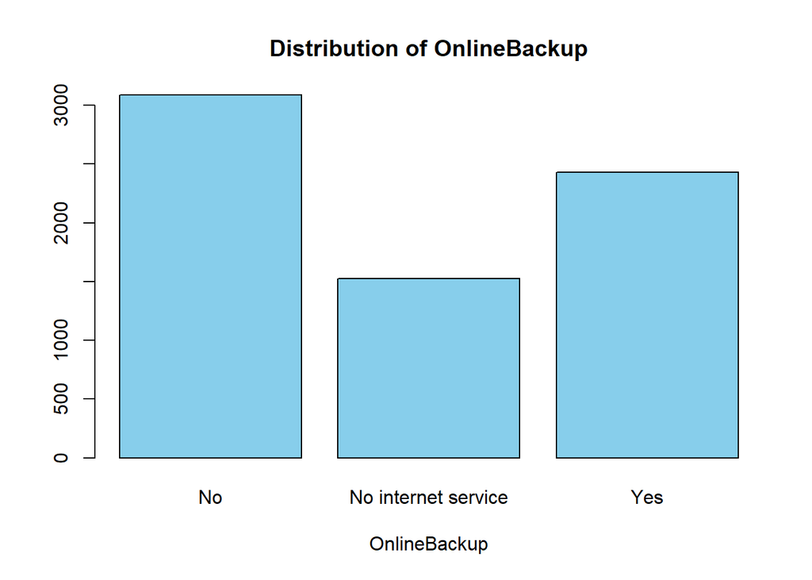

```r
barplot(table(df$OnlineBackup), main = "Distribution of OnlineBackup",xlab = "OnlineBackup",col = "skyblue")
```

```r
# Check concistency
sum(df$OnlineBackup == "No internet service") #1526
```

```
## [1] 1526
```

```r
sum(df$OnlineSecurity == "No internet service") #1526
```

```
## [1] 1526
```

#### 12. DeviceProtection

Categorical variable with 3 levels: No/No internet service/Yes

```r
table(df$DeviceProtection)
```

```
##
##                  No No internet service                 Yes
##                3095                1526                2422
```

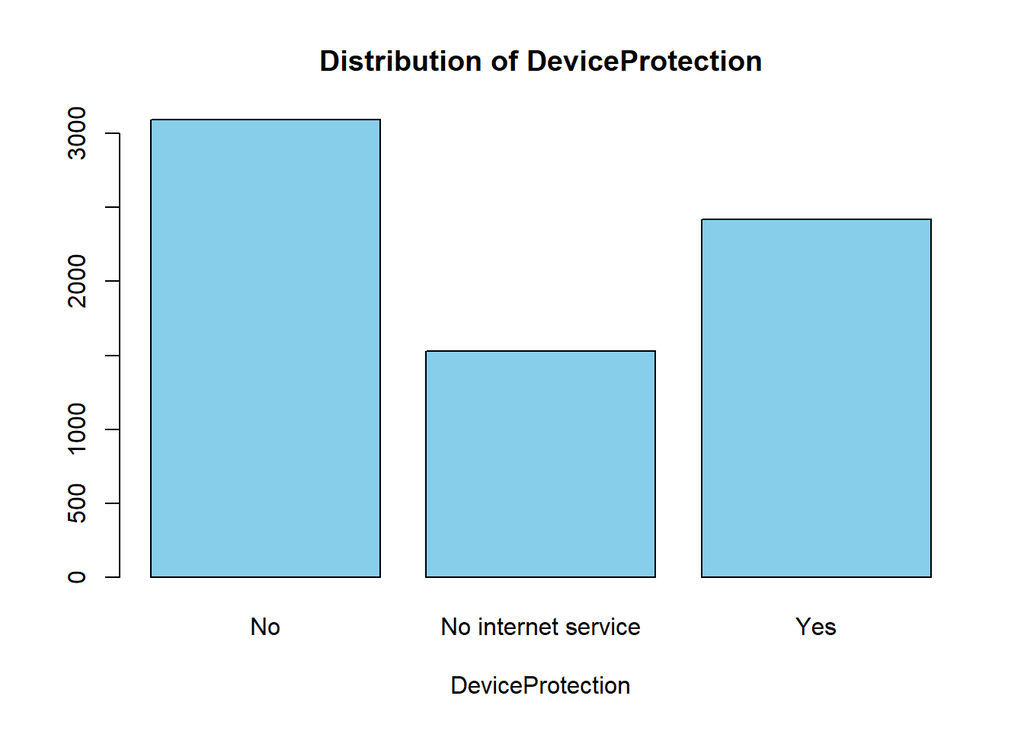

```r
barplot(table(df$DeviceProtection), main = "Distribution of DeviceProtection",xlab = "DeviceProtection",col = "skyblue")
```

```r
# Check concistency
sum(df$OnlineSecurity == "No internet service") #1526
```

```
## [1] 1526
```

```r
sum(df$DeviceProtection == "No internet service") #1526
```

```
## [1] 1526
```

#### 13. TechSupport

Categorical variable with 3 levels: No/No internet service/Yes

```r
table(df$TechSupport)
```

```
##
##                  No No internet service                 Yes
##                3473                1526                2044
```

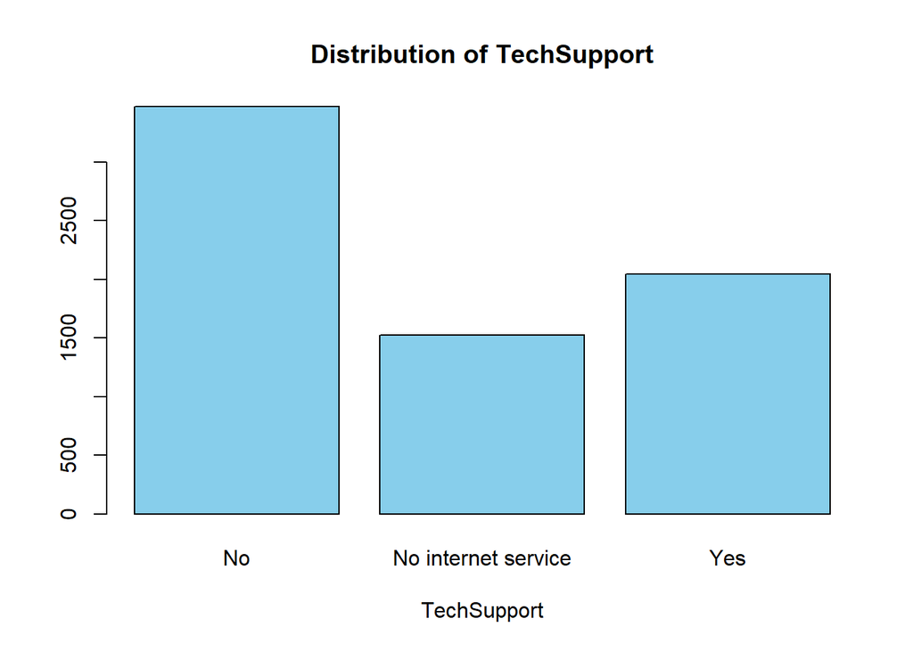

```r
barplot(table(df$TechSupport), main = "Distribution of TechSupport",xlab = "TechSupport",col = "skyblue")
```

```r
#Check consistency
sum(df$DeviceProtection == "No internet service") #1526
```

```
## [1] 1526
```

```r
sum(df$TechSupport == "No internet service") #1526
```

```
## [1] 1526
```

#### 14. StreamingTV

Categorical variable with 3 levels: No/No internet service/Yes

```r
table(df$StreamingTV)
```

```
##
##                  No No internet service                 Yes
##                2810                1526                2707
```

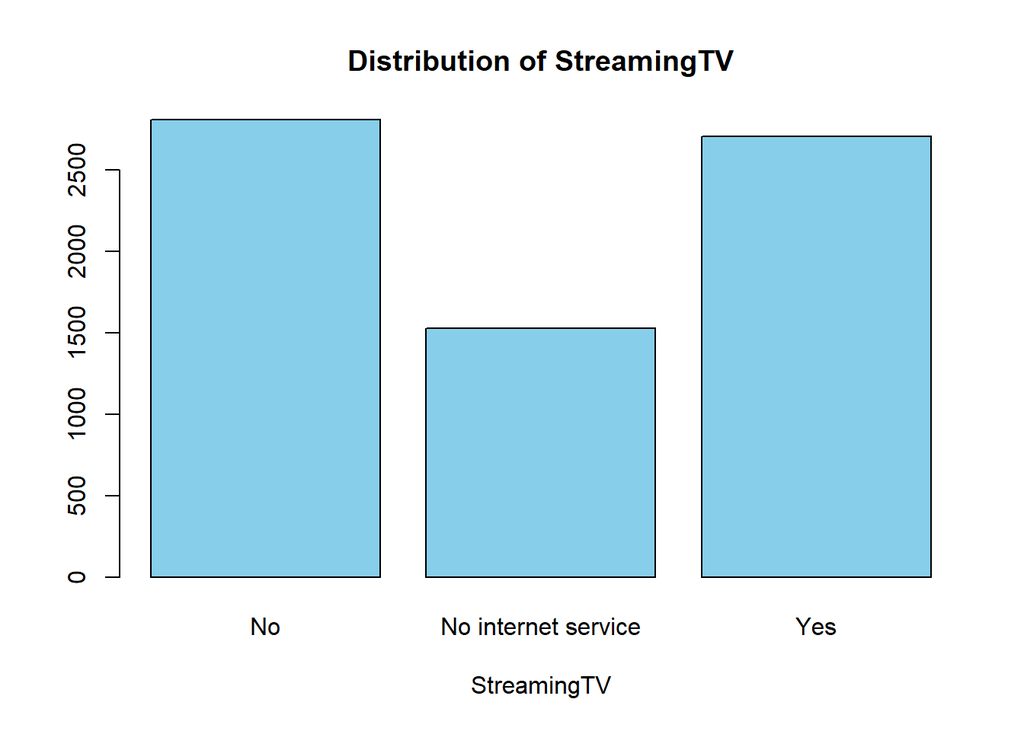

```r
barplot(table(df$StreamingTV), main = "Distribution of StreamingTV",xlab = "StreamingTV",col = "skyblue")
```

```r
#Check consistency
sum(df$TechSupport == "No internet service") #1526
```

```
## [1] 1526
```

```r
sum(df$StreamingTV == "No internet service") #1526
```

```
## [1] 1526
```

#### 15. StreamingMovies

Categorical variable with 3 levels: No/No internet service/Yes

```r
table(df$StreamingMovies)
```

```
##
##                  No No internet service                 Yes
##                2785                1526                2732
```

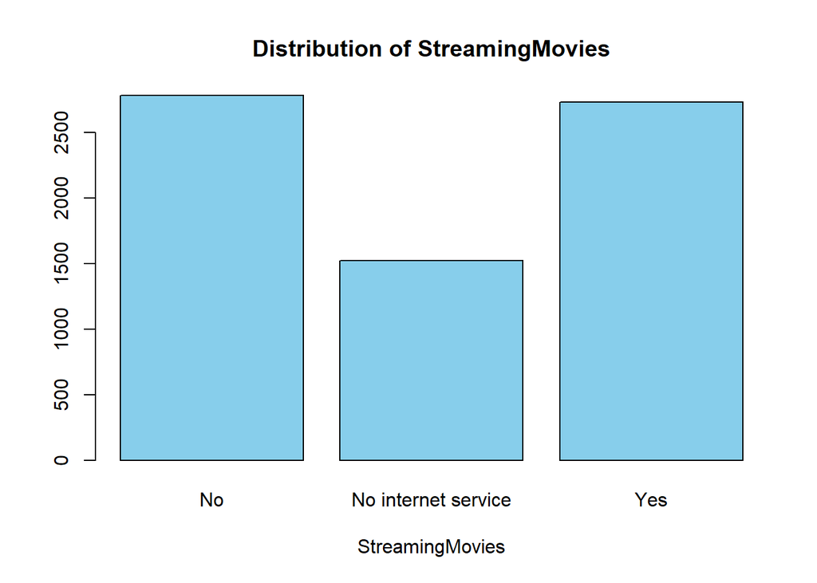

```r
barplot(table(df$StreamingMovies), main = "Distribution of StreamingMovies",xlab = "StreamingMovies",col = "skyblue")
```

```r
#Check consistency
sum(df$StreamingTV == "No internet service") #1526
```

```
## [1] 1526
```

```r
sum(df$StreamingMovies == "No internet service") #1526
```

```
## [1] 1526
```

### Customer account data

#### 16. Contract

Categorical variable with 3 levels: Month-to-month/One year/Two year

```r
table(df$Contract)
```

```
##
## Month-to-month       One year       Two year
##           3875           1473           1695
```

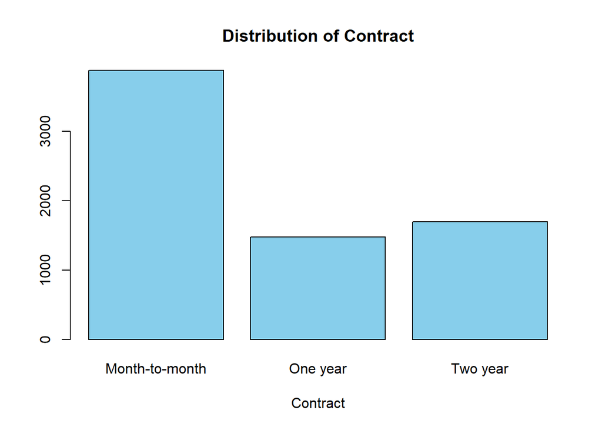

```r
barplot(table(df$Contract), main = "Distribution of Contract",xlab = "Contract",col = "skyblue")
```

#### 17. PaperlessBilling

It is a binary variable. Levels: No/Yes

```r
table(df$PaperlessBilling)
```

```
##
##   No  Yes
## 2872 4171
```

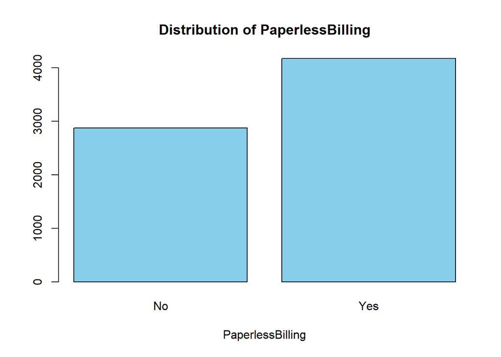

```r
barplot(table(df$PaperlessBilling), main = "Distribution of PaperlessBilling",xlab = "PaperlessBilling",col = "skyblue")
```

#### 18. PaymentMethod

Categorical variable with 4 levels: Bank transfer (automatic)/Credit card (automatic)/Electronic check/Mailed check

```r
table(df$PaymentMethod)
```

```
##
## Bank transfer (automatic)   Credit card (automatic)          Electronic check
##                      1544                      1522                      2365
##              Mailed check
##                      1612
```

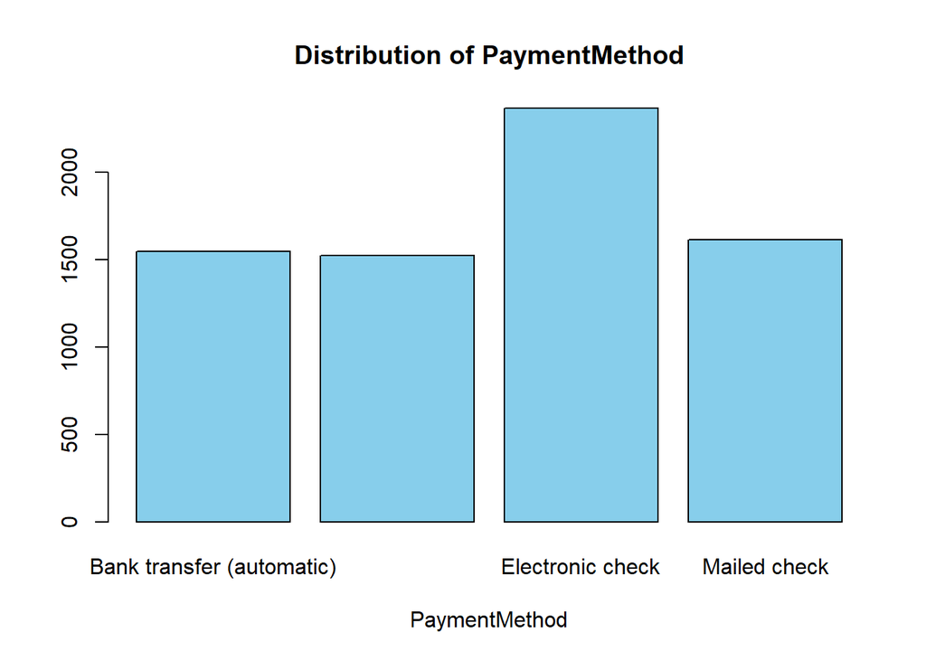

```r
barplot(table(df$PaymentMethod), main = "Distribution of PaymentMethod",xlab = "PaymentMethod",col = "skyblue")
```

#### 19. MonthlyCharges

It is a numerical variable.

```r
summary(df$MonthlyCharges)
```

```
##    Min. 1st Qu.  Median    Mean 3rd Qu.    Max.
##   18.25   35.50   70.35   64.76   89.85  118.75
```

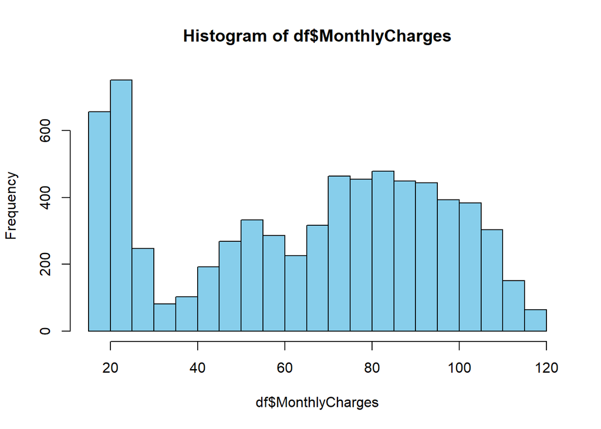

```r
hist(df$MonthlyCharges,breaks=20,col="skyblue")
```

Let’s look for *outliers*.

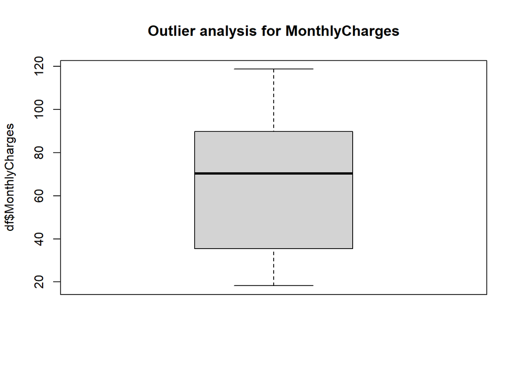

```r
Boxplot(df$MonthlyCharges, main="Outlier analysis for MonthlyCharges")
```

```r
sm <- summary(df$MonthlyCharges)
iqr <- sm["3rd Qu."] - sm["1st Qu."]
# Mild Outliers
mild_ub <- sm["3rd Qu."] + 1.5 * iqr
mild_lb <- sm["1st Qu."] - 1.5 * iqr
length(which(df$MonthlyCharges > mild_ub | df$MonthlyCharges < mild_lb)) # number of mild outliers
```

```
## [1] 0
```

```r
# Severe Outliers
severe_ub <- sm["3rd Qu."] + 3 * iqr
severe_lb <- sm["1st Qu."] - 3 * iqr
length(which(df$MonthlyCharges > severe_ub | df$MonthlyCharges < severe_lb)) # number of severe outliers
```

```
## [1] 0
```

There are no mild nor severe outliers in MonthlyCharges.

#### 20. TotalCharges (numeric)

It is a numerical variable.

```r
summary(df$TotalCharges)
```

```
##    Min. 1st Qu.  Median    Mean 3rd Qu.    Max.    NA's
##    18.8   401.4  1397.5  2283.3  3794.7  8684.8      11
```

```r
sum(is.na(df$TotalCharges))
```

```
## [1] 11
```

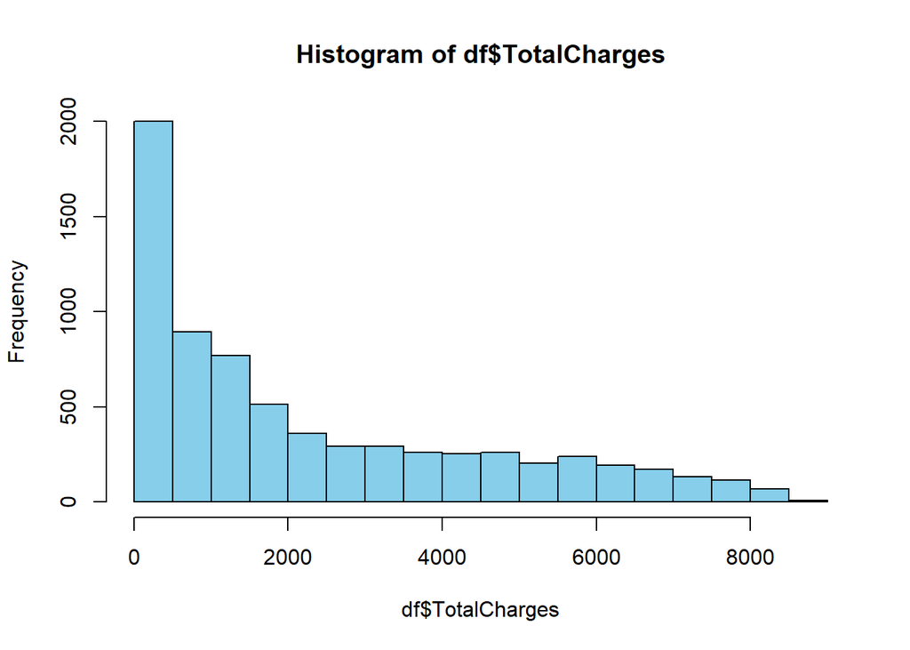

```r
hist(df$TotalCharges,breaks=20,col="skyblue")
```

Let’s look for *outliers*.

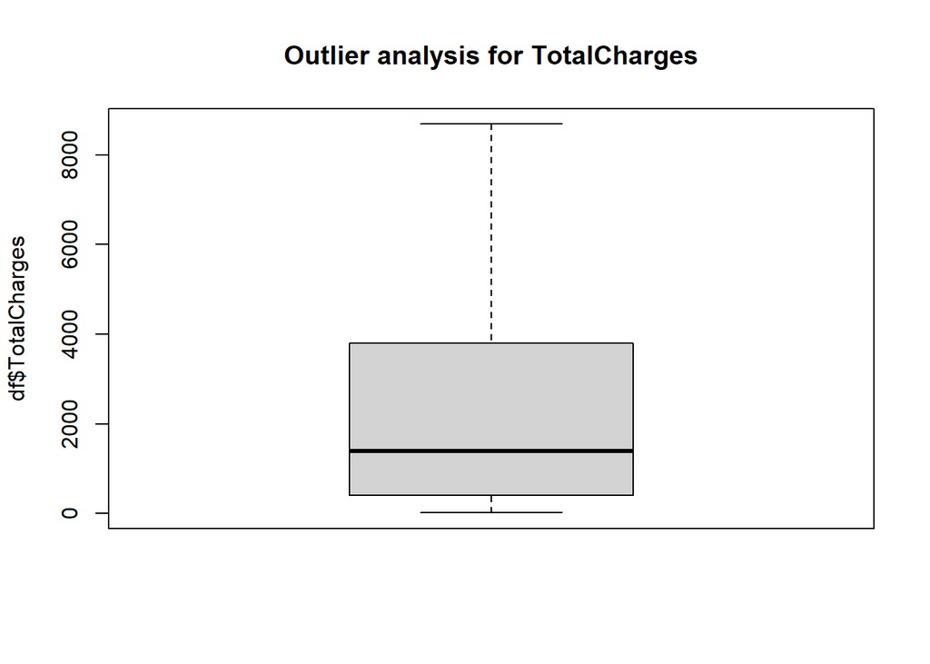

```r
Boxplot(df$TotalCharges, main="Outlier analysis for TotalCharges")
```

```r
sm <- summary(df$TotalCharges)
iqr <- sm["3rd Qu."] - sm["1st Qu."]
# Mild Outliers
mild_ub <- sm["3rd Qu."] + 1.5 * iqr
mild_lb <- sm["1st Qu."] - 1.5 * iqr
length(which(df$TotalCharges > mild_ub | df$TotalCharges < mild_lb)) # number of mild outliers
```

```
## [1] 0
```

```r
# Severe Outliers
severe_ub <- sm["3rd Qu."] + 3 * iqr
severe_lb <- sm["1st Qu."] - 3 * iqr
length(which(df$TotalCharges > severe_ub | df$TotalCharges < severe_lb)) # number of severe outliers
```

```
## [1] 0
```

There are no mild nor severe outliers.

### Target:

#### 21. Churn

```r
table(df$Churn)
```

```
##
##   No  Yes
## 5174 1869
```

```r
prop.table(table(df$Churn))
```

```
##
##        No       Yes
## 0.7346301 0.2653699
```

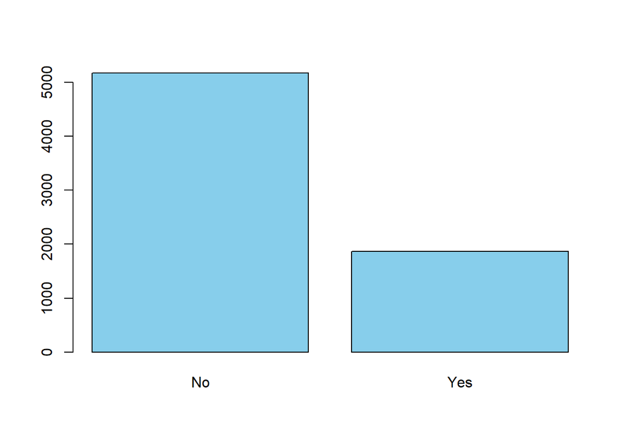

```r
barplot(table(df$Churn), col="skyblue")
```

## Data preprocessing

### Recode variables into correct type

We shall reconvert the type of certain variables that are encoded with wrong type. First, we convert the character variables (except the ID) into factors.

```r
char_cols <- which(sapply(df, is.character))
df[, char_cols[-1]]<- lapply(df[, char_cols[-1]], as.factor)
```

Also, we convert the numerical variable SeniorCitizen into a factor.

```r
df$SeniorCitizen<- factor(df$SeniorCitizen)
```

```r
summary(df)
```

```
##   customerID           gender     SeniorCitizen Partner    Dependents
##  Length:7043        Female:3488   0:5901        No :3641   No :4933
##  Class :character   Male  :3555   1:1142        Yes:3402   Yes:2110
##  Mode  :character
##
##
##
##
##      tenure      PhoneService          MultipleLines     InternetService
##  Min.   : 0.00   No : 682     No              :3390   DSL        :2421
##  1st Qu.: 9.00   Yes:6361     No phone service: 682   Fiber optic:3096
##  Median :29.00                Yes             :2971   No         :1526
##  Mean   :32.37
##  3rd Qu.:55.00
##  Max.   :72.00
##
##              OnlineSecurity              OnlineBackup
##  No                 :3498   No                 :3088
##  No internet service:1526   No internet service:1526
##  Yes                :2019   Yes                :2429
##
##
##
##
##             DeviceProtection              TechSupport
##  No                 :3095    No                 :3473
##  No internet service:1526    No internet service:1526
##  Yes                :2422    Yes                :2044
##
##
##
##
##               StreamingTV              StreamingMovies           Contract
##  No                 :2810   No                 :2785   Month-to-month:3875
##  No internet service:1526   No internet service:1526   One year      :1473
##  Yes                :2707   Yes                :2732   Two year      :1695
##
##
##
##
##  PaperlessBilling                   PaymentMethod  MonthlyCharges
##  No :2872         Bank transfer (automatic):1544   Min.   : 18.25
##  Yes:4171         Credit card (automatic)  :1522   1st Qu.: 35.50
##                   Electronic check         :2365   Median : 70.35
##                   Mailed check             :1612   Mean   : 64.76
##                                                    3rd Qu.: 89.85
##                                                    Max.   :118.75
##
##   TotalCharges    Churn
##  Min.   :  18.8   No :5174
##  1st Qu.: 401.4   Yes:1869
##  Median :1397.5
##  Mean   :2283.3
##  3rd Qu.:3794.7
##  Max.   :8684.8
##  NA's   :11
```

```r
str(df)
```

```
## 'data.frame':    7043 obs. of  21 variables:
##  $ customerID      : chr  "7590-VHVEG" "5575-GNVDE" "3668-QPYBK" "7795-CFOCW" ...
##  $ gender          : Factor w/ 2 levels "Female","Male": 1 2 2 2 1 1 2 1 1 2 ...
##  $ SeniorCitizen   : Factor w/ 2 levels "0","1": 1 1 1 1 1 1 1 1 1 1 ...
##  $ Partner         : Factor w/ 2 levels "No","Yes": 2 1 1 1 1 1 1 1 2 1 ...
##  $ Dependents      : Factor w/ 2 levels "No","Yes": 1 1 1 1 1 1 2 1 1 2 ...
##  $ tenure          : int  1 34 2 45 2 8 22 10 28 62 ...
##  $ PhoneService    : Factor w/ 2 levels "No","Yes": 1 2 2 1 2 2 2 1 2 2 ...
##  $ MultipleLines   : Factor w/ 3 levels "No","No phone service",..: 2 1 1 2 1 3 3 2 3 1 ...
##  $ InternetService : Factor w/ 3 levels "DSL","Fiber optic",..: 1 1 1 1 2 2 2 1 2 1 ...
##  $ OnlineSecurity  : Factor w/ 3 levels "No","No internet service",..: 1 3 3 3 1 1 1 3 1 3 ...
##  $ OnlineBackup    : Factor w/ 3 levels "No","No internet service",..: 3 1 3 1 1 1 3 1 1 3 ...
##  $ DeviceProtection: Factor w/ 3 levels "No","No internet service",..: 1 3 1 3 1 3 1 1 3 1 ...
##  $ TechSupport     : Factor w/ 3 levels "No","No internet service",..: 1 1 1 3 1 1 1 1 3 1 ...
##  $ StreamingTV     : Factor w/ 3 levels "No","No internet service",..: 1 1 1 1 1 3 3 1 3 1 ...
##  $ StreamingMovies : Factor w/ 3 levels "No","No internet service",..: 1 1 1 1 1 3 1 1 3 1 ...
##  $ Contract        : Factor w/ 3 levels "Month-to-month",..: 1 2 1 2 1 1 1 1 1 2 ...
##  $ PaperlessBilling: Factor w/ 2 levels "No","Yes": 2 1 2 1 2 2 2 1 2 1 ...
##  $ PaymentMethod   : Factor w/ 4 levels "Bank transfer (automatic)",..: 3 4 4 1 3 3 2 4 3 1 ...
##  $ MonthlyCharges  : num  29.9 57 53.9 42.3 70.7 ...
##  $ TotalCharges    : num  29.9 1889.5 108.2 1840.8 151.7 ...
##  $ Churn           : Factor w/ 2 levels "No","Yes": 1 1 2 1 2 2 1 1 2 1 ...
```

### Data imputation

```r
summary(is.na(df))
```

```
##  customerID        gender        SeniorCitizen    Partner
##  Mode :logical   Mode :logical   Mode :logical   Mode :logical
##  FALSE:7043      FALSE:7043      FALSE:7043      FALSE:7043
##
##  Dependents        tenure        PhoneService    MultipleLines
##  Mode :logical   Mode :logical   Mode :logical   Mode :logical
##  FALSE:7043      FALSE:7043      FALSE:7043      FALSE:7043
##
##  InternetService OnlineSecurity  OnlineBackup    DeviceProtection
##  Mode :logical   Mode :logical   Mode :logical   Mode :logical
##  FALSE:7043      FALSE:7043      FALSE:7043      FALSE:7043
##
##  TechSupport     StreamingTV     StreamingMovies  Contract
##  Mode :logical   Mode :logical   Mode :logical   Mode :logical
##  FALSE:7043      FALSE:7043      FALSE:7043      FALSE:7043
##
##  PaperlessBilling PaymentMethod   MonthlyCharges  TotalCharges
##  Mode :logical    Mode :logical   Mode :logical   Mode :logical
##  FALSE:7043       FALSE:7043      FALSE:7043      FALSE:7032
##                                                   TRUE :11
##    Churn
##  Mode :logical
##  FALSE:7043
##
```

Only the variable TotalCharges has NA’s.

```r
df[is.na(df$TotalCharges), ]
```

```
##      customerID gender SeniorCitizen Partner Dependents tenure PhoneService
## 489  4472-LVYGI Female             0     Yes        Yes      0           No
## 754  3115-CZMZD   Male             0      No        Yes      0          Yes
## 937  5709-LVOEQ Female             0     Yes        Yes      0          Yes
## 1083 4367-NUYAO   Male             0     Yes        Yes      0          Yes
## 1341 1371-DWPAZ Female             0     Yes        Yes      0           No
## 3332 7644-OMVMY   Male             0     Yes        Yes      0          Yes
## 3827 3213-VVOLG   Male             0     Yes        Yes      0          Yes
## 4381 2520-SGTTA Female             0     Yes        Yes      0          Yes
## 5219 2923-ARZLG   Male             0     Yes        Yes      0          Yes
## 6671 4075-WKNIU Female             0     Yes        Yes      0          Yes
## 6755 2775-SEFEE   Male             0      No        Yes      0          Yes
##         MultipleLines InternetService      OnlineSecurity        OnlineBackup
## 489  No phone service             DSL                 Yes                  No
## 754                No              No No internet service No internet service
```

[output cut: 45 more lines]

```r
df[df$tenure==0,]
```

```
##      customerID gender SeniorCitizen Partner Dependents tenure PhoneService
## 489  4472-LVYGI Female             0     Yes        Yes      0           No
## 754  3115-CZMZD   Male             0      No        Yes      0          Yes
## 937  5709-LVOEQ Female             0     Yes        Yes      0          Yes
## 1083 4367-NUYAO   Male             0     Yes        Yes      0          Yes
## 1341 1371-DWPAZ Female             0     Yes        Yes      0           No
## 3332 7644-OMVMY   Male             0     Yes        Yes      0          Yes
## 3827 3213-VVOLG   Male             0     Yes        Yes      0          Yes
## 4381 2520-SGTTA Female             0     Yes        Yes      0          Yes
## 5219 2923-ARZLG   Male             0     Yes        Yes      0          Yes
## 6671 4075-WKNIU Female             0     Yes        Yes      0          Yes
## 6755 2775-SEFEE   Male             0      No        Yes      0          Yes
##         MultipleLines InternetService      OnlineSecurity        OnlineBackup
## 489  No phone service             DSL                 Yes                  No
## 754                No              No No internet service No internet service
```

[output cut: 45 more lines]

```r
df[df$TotalCharges==0, ]
```

[output not shown]

```r
summary(df$TotalCharges)
```

```
##    Min. 1st Qu.  Median    Mean 3rd Qu.    Max.    NA's
##    18.8   401.4  1397.5  2283.3  3794.7  8684.8      11
```

The missing data corresponds to the individuals that have not payed yet the charges of the current month, we can guess that are new clients of the company.

Duplicate values: no

```r
dim(df)
```

```
## [1] 7043   21
```

```r
length(unique(df$customerID))
```

```
## [1] 7043
```

El significat d’aquestos NA son que l’individuu encara no se li ha cobrat el charges ja que no ha arribat a final de més. Una possible solució seria que la variable totalcharges prengui el valor de monthlycharges.

Suggerim quan tenure==0 eliminem les observacions enlloc d’imputar-les ja que representen un 0.1% de les dades. NO ELIMINEM FIQUEM 0

```r
ll <- which(is.na(df$TotalCharges))
df[ll,"TotalCharges"] <- 0
summary(is.na(df$TotalCharges))
```

```
##    Mode   FALSE
## logical    7043
```

Això crec que és un pas que està descrit al pdf però no sé perquè s’ha de fer

Create variable adding the total number missing values, outliers and errors. Describe these variables, to which other variables exist higher associations. Compute the correlation with all other variables. Rank these variables according the correlation Compute for every group of individuals (group of age, size of town, singles, married, …) the mean of missing/outliers/errors values. Rank the groups according the computed mean.

### Correlation btween numericals

(no cal)

```r
num_cols <- which(sapply(df, is.numeric))
cor(df[,c(6,19,20)])
```

```
##                   tenure MonthlyCharges TotalCharges
## tenure         1.0000000      0.2478999    0.8261784
## MonthlyCharges 0.2478999      1.0000000    0.6511738
## TotalCharges   0.8261784      0.6511738    1.0000000
```

### Correlation between categorical

The categorical variables MultipleLines and PhoneService are 100% correlated.

```r
contingency_table<-table(df$MultipleLines,df$PhoneService)
sqrt(chisq.test(contingency_table)$statistic / (sum(contingency_table) * (min(dim(contingency_table)) - 1)))
```

```
## X-squared
##         1
```

```r
contingency_table<-table(df$StreamingTV,df$InternetService)
contingency_table<-table(df$OnlineSecurity,df$InternetService)

contingency_table
```

```
##
##                        DSL Fiber optic   No
##   No                  1241        2257    0
##   No internet service    0           0 1526
##   Yes                 1180         839    0
```

### Profiling

```r
res.cat=catdes(df, 21)
res.cat$test.chi2
```

```
##                        p.value df
## Contract         5.863038e-258  2
## OnlineSecurity   2.661150e-185  2
## TechSupport      1.443084e-180  2
## InternetService  9.571788e-160  2
## PaymentMethod    3.682355e-140  3
## OnlineBackup     2.079759e-131  2
## DeviceProtection 5.505219e-122  2
## StreamingMovies   2.667757e-82  2
## StreamingTV       5.528994e-82  2
## PaperlessBilling  2.614597e-58  1
## Dependents        3.276083e-43  1
## SeniorCitizen     9.477904e-37  1
## Partner           1.519037e-36  1
## MultipleLines     3.464383e-03  2
```

```r
res.cat$category
```

```
## $No
##                                          Cla/Mod  Mod/Cla   Global
## Contract=Two year                       97.16814 31.83224 24.06645
## StreamingMovies=No internet service     92.59502 27.30963 21.66690
## StreamingTV=No internet service         92.59502 27.30963 21.66690
## TechSupport=No internet service         92.59502 27.30963 21.66690
## DeviceProtection=No internet service    92.59502 27.30963 21.66690
## OnlineBackup=No internet service        92.59502 27.30963 21.66690
## OnlineSecurity=No internet service      92.59502 27.30963 21.66690
## InternetService=No                      92.59502 27.30963 21.66690
## PaperlessBilling=No                     83.66992 46.44376 40.77808
## Contract=One year                       88.73048 25.26092 20.91438
## OnlineSecurity=Yes                      85.38881 33.32045 28.66676
## TechSupport=Yes                         84.83366 33.51372 29.02172
## Dependents=Yes                          84.54976 34.48009 29.95882
## Partner=Yes                             80.33510 52.82180 48.30328
## SeniorCitizen=0                         76.39383 87.12795 83.78532
## PaymentMethod=Credit card (automatic)   84.75690 24.93235 21.61011
## InternetService=DSL                     81.04089 37.92037 34.37456
## PaymentMethod=Bank transfer (automatic) 83.29016 24.85504 21.92248
## PaymentMethod=Mailed check              80.89330 25.20294 22.88797
## OnlineBackup=Yes                        78.46851 36.83804 34.48814
## DeviceProtection=Yes                    77.49794 36.27754 34.38875
## MultipleLines=No                        74.95575 49.11094 48.13290
## MultipleLines=Yes                       71.39010 40.99343 42.18373
## StreamingMovies=Yes                     70.05857 36.99266 38.79029
## StreamingTV=Yes                         69.92981 36.58678 38.43533
## StreamingTV=No                          66.47687 36.10359 39.89777
## StreamingMovies=No                      66.31957 35.69772 39.54281
## SeniorCitizen=1                         58.31874 12.87205 16.21468
## Partner=No                              67.04202 47.17820 51.69672
## Dependents=No                           68.72086 65.51991 70.04118
## PaperlessBilling=Yes                    66.43491 53.55624 59.22192
## DeviceProtection=No                     60.87237 36.41283 43.94434
## OnlineBackup=No                         60.07124 35.85234 43.84495
## PaymentMethod=Electronic check          54.71459 25.00966 33.57944
## InternetService=Fiber optic             58.10724 34.77000 43.95854
## TechSupport=No                          58.36453 39.17665 49.31137
## OnlineSecurity=No                       58.23328 39.36993 49.66634
## Contract=Month-to-month                 57.29032 42.90684 55.01917
```

[output cut: 104 more lines]

```
## SeniorCitizen=0                          3.024931e-34 -12.202212
## Partner=Yes                              6.170871e-37 -12.696658
## Dependents=Yes                           3.572324e-46 -14.265846
## TechSupport=Yes                          1.323174e-46 -14.334963
## OnlineSecurity=Yes                       1.606459e-50 -14.947938
## Contract=One year                        3.593041e-57 -15.935502
## PaperlessBilling=No                      1.072745e-60 -16.435085
## StreamingMovies=No internet service      6.584621e-98 -20.999812
## StreamingTV=No internet service          6.584621e-98 -20.999812
## TechSupport=No internet service          6.584621e-98 -20.999812
## DeviceProtection=No internet service     6.584621e-98 -20.999812
## OnlineBackup=No internet service         6.584621e-98 -20.999812
## OnlineSecurity=No internet service       6.584621e-98 -20.999812
## InternetService=No                       6.584621e-98 -20.999812
## Contract=Two year                       3.588830e-187 -29.178937
```

```r
res.cat$quanti.var
```

```
##                      Eta2       P-value
## tenure         0.12406504 7.999058e-205
## TotalCharges   0.03933251  2.127212e-63
## MonthlyCharges 0.03738671  2.706646e-60
```

```r
res.cat$quanti
```

```
## $No
##                   v.test Mean in category Overall mean sd in category
## tenure          29.55784         37.56997     32.37115       24.11145
## TotalCharges    16.64270       2549.91144   2279.73430     2329.72904
## MonthlyCharges -16.22582         61.26512     64.76169       31.08964
##                Overall sd       p.value
## tenure           24.55774 5.207314e-192
## TotalCharges   2266.63354  3.418341e-62
## MonthlyCharges   30.08791  3.312724e-59
##
## $Yes
##                   v.test Mean in category Overall mean sd in category
## MonthlyCharges  16.22582         74.44133     64.76169       24.65945
## TotalCharges   -16.64270       1531.79609   2279.73430     1890.31709
## tenure         -29.55784         17.97913     32.37115       19.52590
##                Overall sd       p.value
## MonthlyCharges   30.08791  3.312724e-59
## TotalCharges   2266.63354  3.418341e-62
## tenure           24.55774 5.207314e-192
```

For example, we can analyse in detail the variable “Contract”. For the customers that haven’t churned, the correlation between the ones that have a contract of two year is directly proportional and it’s the highest relation. However, we can see that is the costumer has churned the ones that have a two-year contract have an strong negative correlation. The ones that have a month-to-month contract are the opposite of the previous answer; they have the highest positive correlation with the costumers that have churned and the negative with the ones that haven’t.

Besides the latter variable, we can observe the parameter that have a higher positive correlation with the costumers that churn is the parameter “OnlineSecurity” and “TechSupport” when the answer is “No”. The parameters that have a negative relation with the costumers that churn are when they haven’t hired an Internet Service. We can see that all parameters that have an answer that is “No internet service” have also a negative relation with the response variable “Yes”. We can deduce that they might have multicollinearity with the parameter Internet Service, but we will check it later.

###Modelling

abans o despresss nose ###Data transformations:

Recall that the following variables: OnlineSecurity OnlineBackup DeviceProtection TechSupport StreamingTV

StreamingMovies

are categorical variables with 3 levels: No/No internet service/Yes.

We observe that they contain “No internet service” as a response. We have a variable called *“InternetService”* that is a categorical variable with 3 levels: DSL/Fiber optic/No. Whenever InternetService=“No” implies -> var=“No internet service”. Therefore we decided to transform the level “No internet service” into “No” in the 6 variables above since this variable will specify.

```r
df$OnlineSecurity[df$OnlineSecurity=="No internet service"] <- "No"
df$OnlineBackup[df$OnlineBackup=="No internet service"] <- "No"
df$DeviceProtection[df$DeviceProtection=="No internet service"] <- "No"
df$TechSupport[df$TechSupport=="No internet service"] <- "No"
df$StreamingTV[df$StreamingTV=="No internet service"] <- "No"
df$StreamingMovies[df$StreamingMovies=="No internet service"] <- "No"
### aqui el phone falta explicar
df$MultipleLines[df$MultipleLines=="No phone service"] <- "No"
summary(df)
```

```
##   customerID           gender     SeniorCitizen Partner    Dependents
##  Length:7043        Female:3488   0:5901        No :3641   No :4933
##  Class :character   Male  :3555   1:1142        Yes:3402   Yes:2110
##  Mode  :character
##
##
##
##      tenure      PhoneService          MultipleLines     InternetService
##  Min.   : 0.00   No : 682     No              :4072   DSL        :2421
##  1st Qu.: 9.00   Yes:6361     No phone service:   0   Fiber optic:3096
##  Median :29.00                Yes             :2971   No         :1526
##  Mean   :32.37
##  3rd Qu.:55.00
##  Max.   :72.00
##              OnlineSecurity              OnlineBackup
##  No                 :5024   No                 :4614
##  No internet service:   0   No internet service:   0
##  Yes                :2019   Yes                :2429
##
##
##
##             DeviceProtection              TechSupport
##  No                 :4621    No                 :4999
##  No internet service:   0    No internet service:   0
##  Yes                :2422    Yes                :2044
##
##
##
##               StreamingTV              StreamingMovies           Contract
##  No                 :4336   No                 :4311   Month-to-month:3875
##  No internet service:   0   No internet service:   0   One year      :1473
##  Yes                :2707   Yes                :2732   Two year      :1695
##
##
##
##  PaperlessBilling                   PaymentMethod  MonthlyCharges
##  No :2872         Bank transfer (automatic):1544   Min.   : 18.25
##  Yes:4171         Credit card (automatic)  :1522   1st Qu.: 35.50
##                   Electronic check         :2365   Median : 70.35
##                   Mailed check             :1612   Mean   : 64.76
##                                                    3rd Qu.: 89.85
##                                                    Max.   :118.75
##   TotalCharges    Churn
##  Min.   :   0.0   No :5174
##  1st Qu.: 398.6   Yes:1869
##  Median :1394.5
##  Mean   :2279.7
##  3rd Qu.:3786.6
##  Max.   :8684.8
```

Modelling: Train - test → dubte: abans o després de balancejar les dades? The dataset is imbalanced. Use only glm() modeling tools (parametric and traditional statistical models, baseline for comparison to ML approaches being developed in other subjects) Assessment metric: area under the ROC curve score and confusion table prediction capability analysis (recall, F1-score, etc) for train sample and confusion table for test sample

```r
set.seed(1234)
m <- floor(0.7*nrow(df))
train_d <- sample(seq_len(nrow(df)),size = m)

train <- df[train_d,]
test <- df[-train_d,]

names(df)
```

```
##  [1] "customerID"       "gender"           "SeniorCitizen"    "Partner"
##  [5] "Dependents"       "tenure"           "PhoneService"     "MultipleLines"
##  [9] "InternetService"  "OnlineSecurity"   "OnlineBackup"     "DeviceProtection"
## [13] "TechSupport"      "StreamingTV"      "StreamingMovies"  "Contract"
## [17] "PaperlessBilling" "PaymentMethod"    "MonthlyCharges"   "TotalCharges"
## [21] "Churn"
```

Target variable is Churn.

We start the modeling by the null model.

```r
mod0 <- glm(Churn ~ 1, data=train, family=binomial)
mod0$deviance
```

```
## [1] 5694.218
```

We continue by adding the numerical variables and assessing the model.

```r
which(sapply(df, is.numeric))
```

```
##         tenure MonthlyCharges   TotalCharges
##              6             19             20
```

We start by *tenure*

```r
mod1 <- glm(Churn ~ tenure, data=train, family=binomial)
mod1$deviance;AIC(mod0,mod1) #summary(mod1)
```

```
## [1] 5040.677
```

```
##      df      AIC
## mod0  1 5696.218
## mod1  2 5044.677
```

```r
anova( mod0, mod1,  test="Chisq")
```

```
## Analysis of Deviance Table
##
## Model 1: Churn ~ 1
## Model 2: Churn ~ tenure
##   Resid. Df Resid. Dev Df Deviance  Pr(>Chi)
## 1      4929     5694.2
## 2      4928     5040.7  1   653.54 < 2.2e-16 ***
## ---
## Signif. codes:  0 '***' 0.001 '**' 0.01 '*' 0.05 '.' 0.1 ' ' 1
```

we use a second order variable

```r
mod1q <- glm(Churn ~ tenure + I(tenure^2), data=train, family=binomial)
summary(mod1q)
```

```
##
## Call:
## glm(formula = Churn ~ tenure + I(tenure^2), family = binomial,
##     data = train)
##
## Coefficients:
##               Estimate Std. Error z value Pr(>|z|)
## (Intercept)  1.184e-01  6.469e-02   1.831  0.06709 .
## tenure      -5.271e-02  5.639e-03  -9.347  < 2e-16 ***
## I(tenure^2)  2.268e-04  8.428e-05   2.691  0.00713 **
## ---
## Signif. codes:  0 '***' 0.001 '**' 0.01 '*' 0.05 '.' 0.1 ' ' 1
##
## (Dispersion parameter for binomial family taken to be 1)
##
##     Null deviance: 5694.2  on 4929  degrees of freedom
## Residual deviance: 5033.5  on 4927  degrees of freedom
## AIC: 5039.5
##
## Number of Fisher Scoring iterations: 5
```

```r
anova( mod1, mod1q,  test="Chisq")
```

```
## Analysis of Deviance Table
##
## Model 1: Churn ~ tenure
## Model 2: Churn ~ tenure + I(tenure^2)
##   Resid. Df Resid. Dev Df Deviance Pr(>Chi)
## 1      4928     5040.7
## 2      4927     5033.5  1    7.153 0.007484 **
## ---
## Signif. codes:  0 '***' 0.001 '**' 0.01 '*' 0.05 '.' 0.1 ' ' 1
```

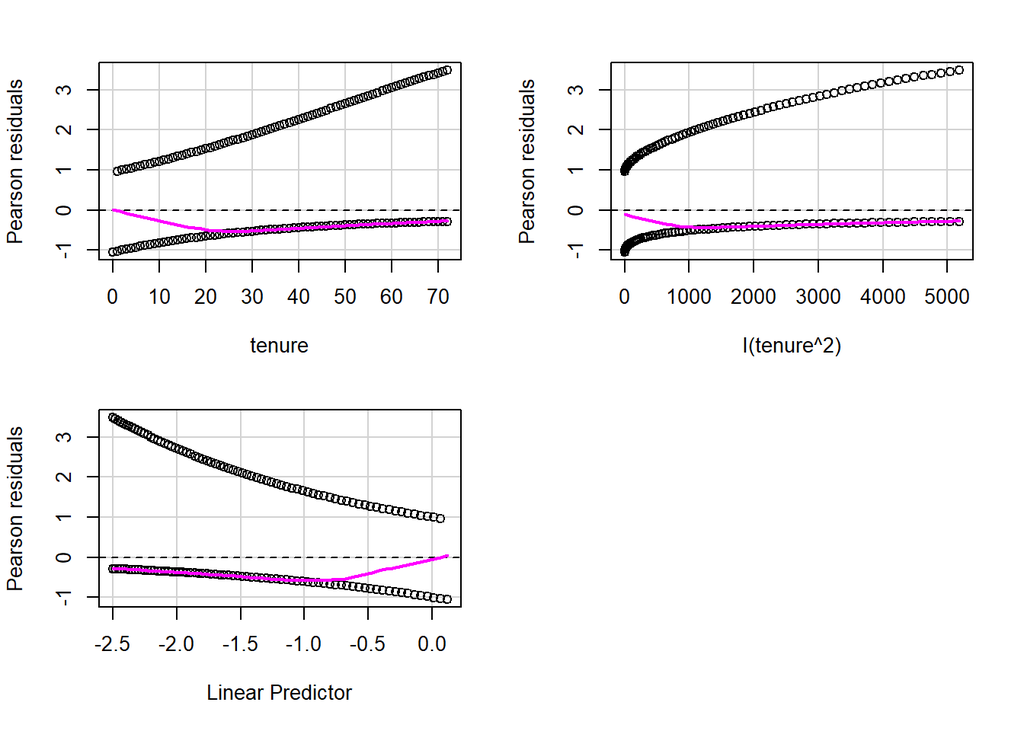

```
##             Test stat Pr(>|Test stat|)
## tenure          0.000                1
## I(tenure^2)    42.054         8.88e-11 ***
## ---
## Signif. codes:  0 '***' 0.001 '**' 0.01 '*' 0.05 '.' 0.1 ' ' 1
```

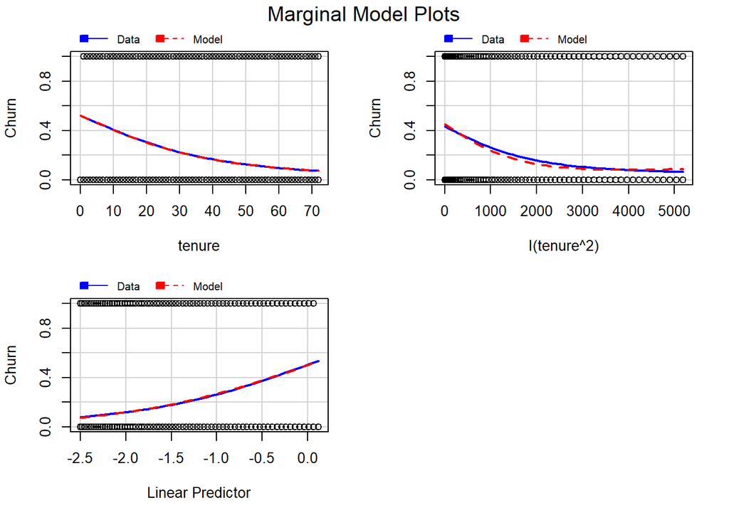

```r
residualPlots(mod1q); marginalModelPlots(mod1q)
```

Add MonthlyCharges

```r
mod2 <- glm(Churn ~ tenure + I(tenure^2)+ MonthlyCharges, data=train, family=binomial)
mod2$deviance
```

```
## [1] 4451.056
```

```r
anova( mod1, mod2,  test="Chisq")
```

```
## Analysis of Deviance Table
##
## Model 1: Churn ~ tenure
## Model 2: Churn ~ tenure + I(tenure^2) + MonthlyCharges
##   Resid. Df Resid. Dev Df Deviance  Pr(>Chi)
## 1      4928     5040.7
## 2      4926     4451.1  2   589.62 < 2.2e-16 ***
## ---
## Signif. codes:  0 '***' 0.001 '**' 0.01 '*' 0.05 '.' 0.1 ' ' 1
```

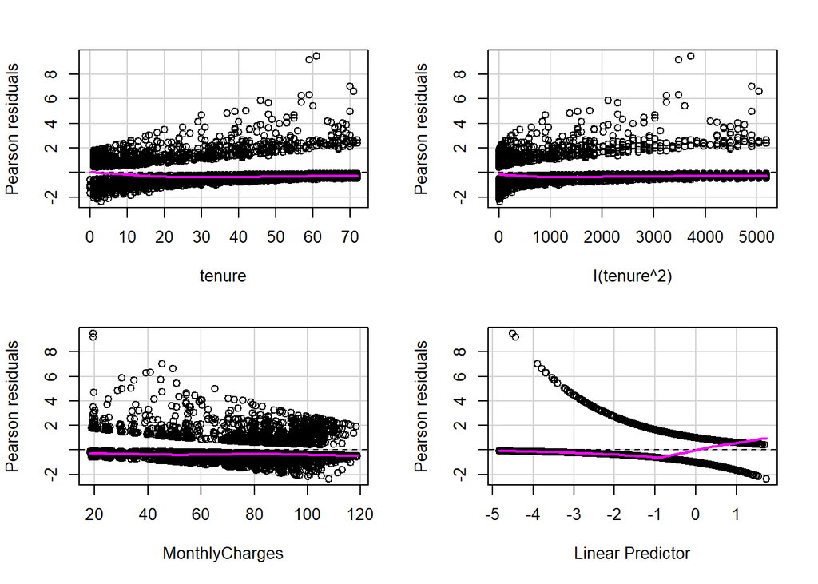

```
##                Test stat Pr(>|Test stat|)
## tenure            0.0000           1.0000
## I(tenure^2)      60.6733        6.772e-15 ***
## MonthlyCharges    0.1444           0.7039
## ---
## Signif. codes:  0 '***' 0.001 '**' 0.01 '*' 0.05 '.' 0.1 ' ' 1
```

```r
residualPlots(mod2)
```

consider interactions

```r
mod2i <- glm(Churn ~ (tenure + I(tenure^2) ) *MonthlyCharges, data=train, family=binomial)
mod2i$deviance
```

```
## [1] 4430.823
```

```r
anova( mod2, mod2i,  test="Chisq")
```

```
## Analysis of Deviance Table
##
## Model 1: Churn ~ tenure + I(tenure^2) + MonthlyCharges
## Model 2: Churn ~ (tenure + I(tenure^2)) * MonthlyCharges
##   Resid. Df Resid. Dev Df Deviance Pr(>Chi)
## 1      4926     4451.1
## 2      4924     4430.8  2   20.233 4.04e-05 ***
## ---
## Signif. codes:  0 '***' 0.001 '**' 0.01 '*' 0.05 '.' 0.1 ' ' 1
```

```r
summary(mod2i)
```

```
##
## Call:
## glm(formula = Churn ~ (tenure + I(tenure^2)) * MonthlyCharges,
##     family = binomial, data = train)
##
## Coefficients:
##                              Estimate Std. Error z value Pr(>|z|)
## (Intercept)                -1.218e+00  1.721e-01  -7.076 1.48e-12 ***
## tenure                     -1.591e-01  1.932e-02  -8.232  < 2e-16 ***
## I(tenure^2)                 1.631e-03  3.039e-04   5.368 7.96e-08 ***
## MonthlyCharges              2.658e-02  2.662e-03   9.983  < 2e-16 ***
## tenure:MonthlyCharges       1.058e-03  2.415e-04   4.382 1.18e-05 ***
## I(tenure^2):MonthlyCharges -1.607e-05  3.607e-06  -4.456 8.36e-06 ***
## ---
## Signif. codes:  0 '***' 0.001 '**' 0.01 '*' 0.05 '.' 0.1 ' ' 1
##
## (Dispersion parameter for binomial family taken to be 1)
##
##     Null deviance: 5694.2  on 4929  degrees of freedom
## Residual deviance: 4430.8  on 4924  degrees of freedom
## AIC: 4442.8
##
## Number of Fisher Scoring iterations: 6
```

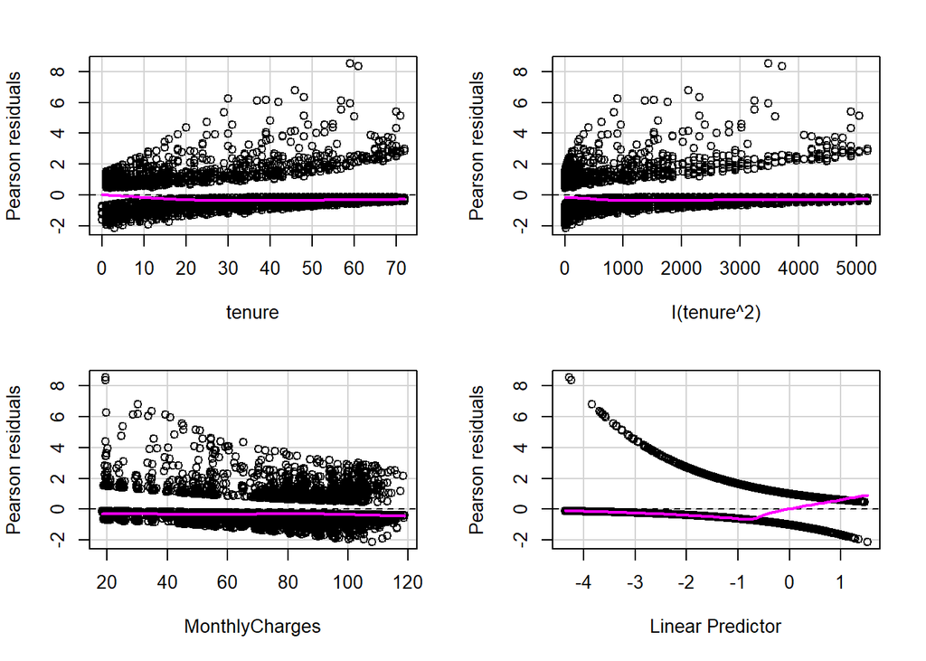

```
##                Test stat Pr(>|Test stat|)
## tenure            0.0000           1.0000
## I(tenure^2)      42.1055        8.648e-11 ***
## MonthlyCharges    2.2123           0.1369
## ---
## Signif. codes:  0 '***' 0.001 '**' 0.01 '*' 0.05 '.' 0.1 ' ' 1
```

```r
residualPlots(mod2i)
```

Add TotalCharges

```r
mod3 <- glm(Churn ~ (tenure + I(tenure^2) ) *MonthlyCharges + TotalCharges, data=train, family=binomial)
mod3$deviance
```

```
## [1] 4429.874
```

```r
anova( mod2i, mod3,  test="Chisq")
```

```
## Analysis of Deviance Table
##
## Model 1: Churn ~ (tenure + I(tenure^2)) * MonthlyCharges
## Model 2: Churn ~ (tenure + I(tenure^2)) * MonthlyCharges + TotalCharges
##   Resid. Df Resid. Dev Df Deviance Pr(>Chi)
## 1      4924     4430.8
## 2      4923     4429.9  1  0.94858   0.3301
```

```r
summary(mod3)
```

```
##
## Call:
## glm(formula = Churn ~ (tenure + I(tenure^2)) * MonthlyCharges +
##     TotalCharges, family = binomial, data = train)
##
## Coefficients:
##                              Estimate Std. Error z value Pr(>|z|)
## (Intercept)                -1.219e+00  1.722e-01  -7.082 1.42e-12 ***
## tenure                     -1.590e-01  1.933e-02  -8.228  < 2e-16 ***
## I(tenure^2)                 1.631e-03  3.040e-04   5.365 8.10e-08 ***
## MonthlyCharges              2.659e-02  2.663e-03   9.987  < 2e-16 ***
## TotalCharges                5.823e-04  5.983e-04   0.973    0.330
## tenure:MonthlyCharges       4.768e-04  6.441e-04   0.740    0.459
## I(tenure^2):MonthlyCharges -1.610e-05  3.608e-06  -4.461 8.16e-06 ***
## ---
## Signif. codes:  0 '***' 0.001 '**' 0.01 '*' 0.05 '.' 0.1 ' ' 1
##
## (Dispersion parameter for binomial family taken to be 1)
##
##     Null deviance: 5694.2  on 4929  degrees of freedom
## Residual deviance: 4429.9  on 4923  degrees of freedom
## AIC: 4443.9
##
## Number of Fisher Scoring iterations: 6
```

```r
vif(mod3)
```

```
## there are higher-order terms (interactions) in this model
## consider setting type = 'predictor'; see ?vif
```

```
##                     tenure                I(tenure^2)
##                 128.619300                 143.500220
##             MonthlyCharges               TotalCharges
##                   3.705695                1197.593887
##      tenure:MonthlyCharges I(tenure^2):MonthlyCharges
##                1383.184568                 185.756036
```

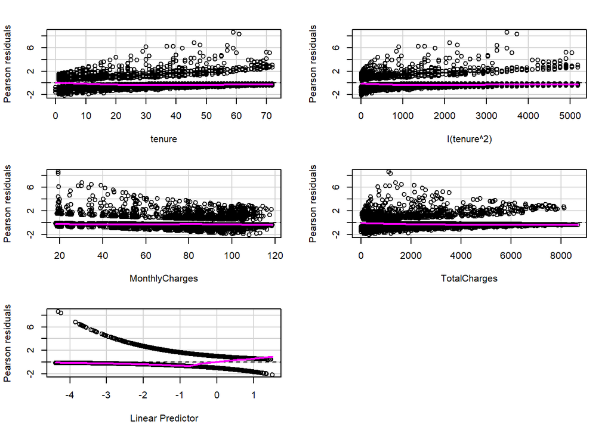

```
##                Test stat Pr(>|Test stat|)
## tenure            0.0000           1.0000
## I(tenure^2)      41.9283        9.468e-11 ***
## MonthlyCharges    2.1996           0.1380
## TotalCharges      0.7990           0.3714
## ---
## Signif. codes:  0 '***' 0.001 '**' 0.01 '*' 0.05 '.' 0.1 ' ' 1
```

```r
residualPlots(mod3)
```

It is not significant enough. We don’t add it in our model. We can also see that *TotalCHarges* has a high VIF, so it has high multicollinearity.

```r
mod3.1 <- glm(Churn ~ (tenure + I(tenure^2) ) + MonthlyCharges , data=train, family=binomial)
mod3.1$deviance
```

```
## [1] 4451.056
```

```r
anova( mod3, mod3.1,  test="Chisq")
```

```
## Analysis of Deviance Table
##
## Model 1: Churn ~ (tenure + I(tenure^2)) * MonthlyCharges + TotalCharges
## Model 2: Churn ~ (tenure + I(tenure^2)) + MonthlyCharges
##   Resid. Df Resid. Dev Df Deviance  Pr(>Chi)
## 1      4923     4429.9
## 2      4926     4451.1 -3  -21.182 9.651e-05 ***
## ---
## Signif. codes:  0 '***' 0.001 '**' 0.01 '*' 0.05 '.' 0.1 ' ' 1
```

```r
summary(mod3.1)
```

```
##
## Call:
## glm(formula = Churn ~ (tenure + I(tenure^2)) + MonthlyCharges,
##     family = binomial, data = train)
##
## Coefficients:
##                  Estimate Std. Error z value Pr(>|z|)
## (Intercept)    -1.737e+00  1.112e-01 -15.616  < 2e-16 ***
## tenure         -7.836e-02  6.219e-03 -12.601  < 2e-16 ***
## I(tenure^2)     3.624e-04  8.887e-05   4.078 4.55e-05 ***
## MonthlyCharges  3.432e-02  1.603e-03  21.412  < 2e-16 ***
## ---
## Signif. codes:  0 '***' 0.001 '**' 0.01 '*' 0.05 '.' 0.1 ' ' 1
##
## (Dispersion parameter for binomial family taken to be 1)
##
##     Null deviance: 5694.2  on 4929  degrees of freedom
## Residual deviance: 4451.1  on 4926  degrees of freedom
## AIC: 4459.1
##
## Number of Fisher Scoring iterations: 5
```

```r
vif(mod3.1)
```

```
##         tenure    I(tenure^2) MonthlyCharges
##      13.254769      12.452456       1.360702
```

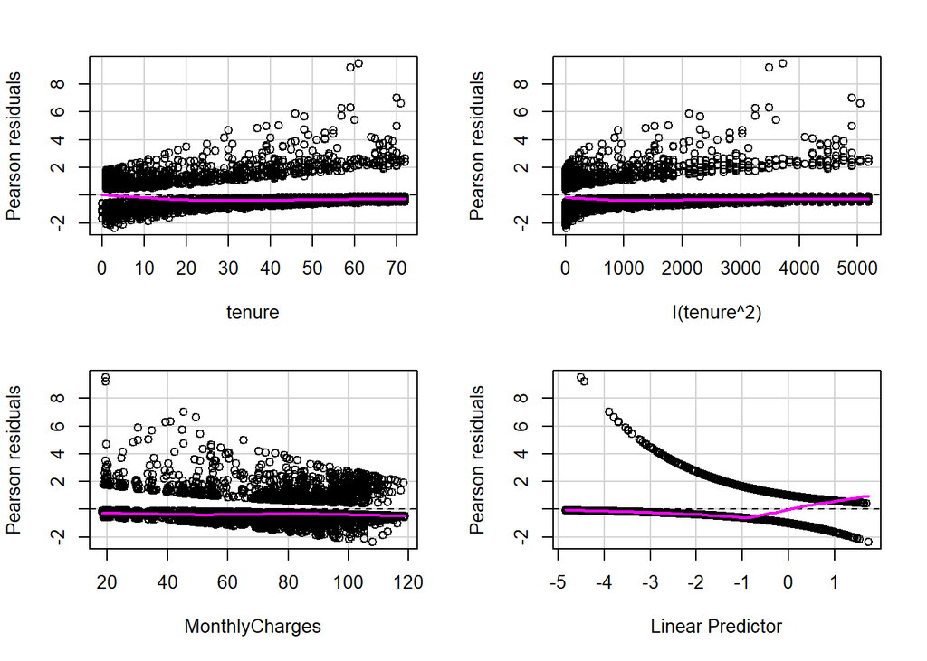

```
##                Test stat Pr(>|Test stat|)
## tenure            0.0000           1.0000
## I(tenure^2)      60.6733        6.772e-15 ***
## MonthlyCharges    0.1444           0.7039
## ---
## Signif. codes:  0 '***' 0.001 '**' 0.01 '*' 0.05 '.' 0.1 ' ' 1
```

```r
residualPlots(mod3.1)
```

```r
mod3.2 <- glm(Churn ~ tenure + MonthlyCharges , data=train, family=binomial)
mod3.2$deviance
```

```
## [1] 4467.45
```

```r
anova( mod3.1, mod3.2,  test="Chisq")
```

```
## Analysis of Deviance Table
##
## Model 1: Churn ~ (tenure + I(tenure^2)) + MonthlyCharges
## Model 2: Churn ~ tenure + MonthlyCharges
##   Resid. Df Resid. Dev Df Deviance  Pr(>Chi)
## 1      4926     4451.1
## 2      4927     4467.5 -1  -16.394 5.145e-05 ***
## ---
## Signif. codes:  0 '***' 0.001 '**' 0.01 '*' 0.05 '.' 0.1 ' ' 1
```

```r
summary(mod3.2) #aic 4473.5
```

```
##
## Call:
## glm(formula = Churn ~ tenure + MonthlyCharges, family = binomial,
##     data = train)
##
## Coefficients:
##                 Estimate Std. Error z value Pr(>|z|)
## (Intercept)    -1.878261   0.105561  -17.79   <2e-16 ***
## tenure         -0.054752   0.002028  -27.00   <2e-16 ***
## MonthlyCharges  0.033675   0.001574   21.39   <2e-16 ***
## ---
## Signif. codes:  0 '***' 0.001 '**' 0.01 '*' 0.05 '.' 0.1 ' ' 1
##
## (Dispersion parameter for binomial family taken to be 1)
##
##     Null deviance: 5694.2  on 4929  degrees of freedom
## Residual deviance: 4467.5  on 4927  degrees of freedom
## AIC: 4473.5
##
## Number of Fisher Scoring iterations: 5
```

```r
vif(mod3.2)
```

```
##         tenure MonthlyCharges
##       1.299246       1.299246
```

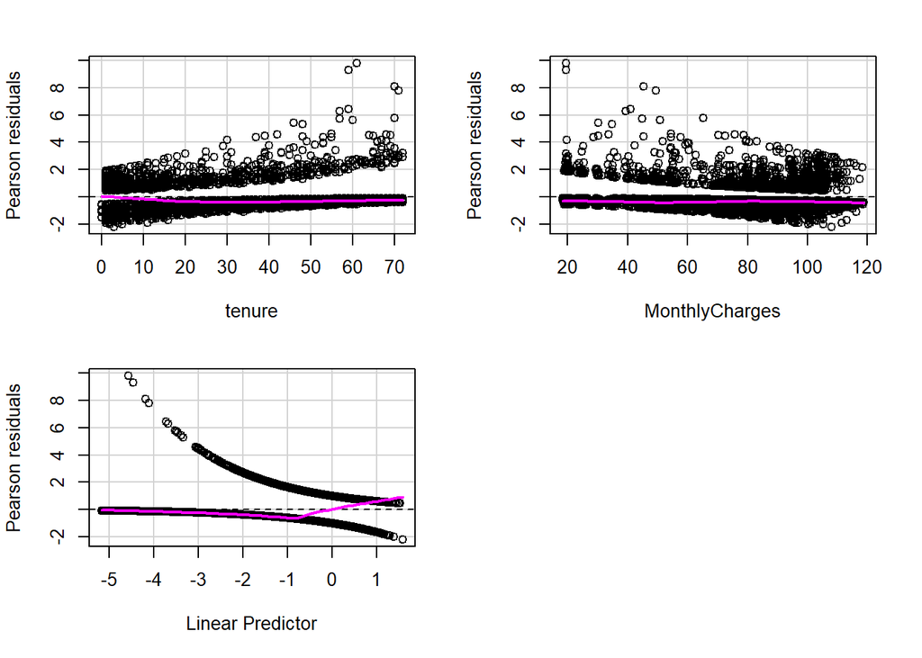

```
##                Test stat Pr(>|Test stat|)
## tenure           16.3940        5.145e-05 ***
## MonthlyCharges    0.0131            0.909
## ---
## Signif. codes:  0 '***' 0.001 '**' 0.01 '*' 0.05 '.' 0.1 ' ' 1
```

```r
residualPlots(mod3.2)
```

##Overdispersion

##Inlfuential data

```r
infl <- influence.measures(mod3.2)
infl$infmat
```

[output not shown]

[output cut: 9847 more lines]

```r
cooks.distance(mod3.2)
```

[output not shown]

[output cut: 1589 more lines]

[output not shown]

```r
sum(residuals(mod3.2,'deviance')^2)
```

```
## [1] 4467.45
```

```r
sum(residuals(mod3.2,'pearson')^2)
```

```
## [1] 4873.989
```

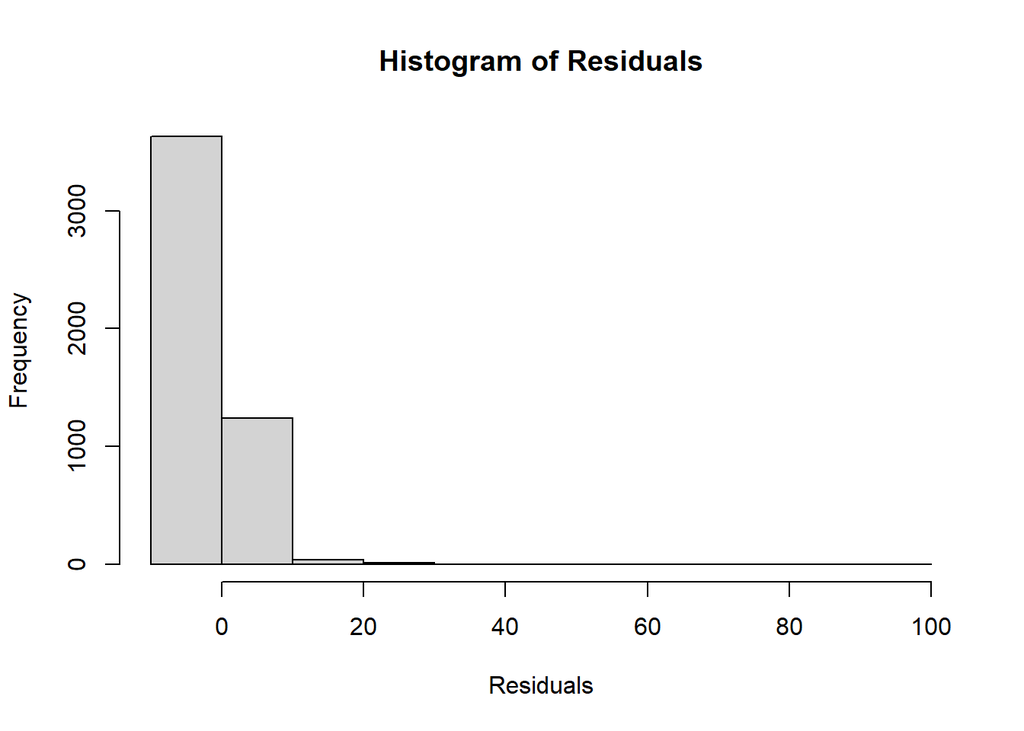

```r
res_3.2 <- mod3.2$residuals

# Plotting a histogram of residuals
hist(res_3.2, main = "Histogram of Residuals", xlab = "Residuals")
```

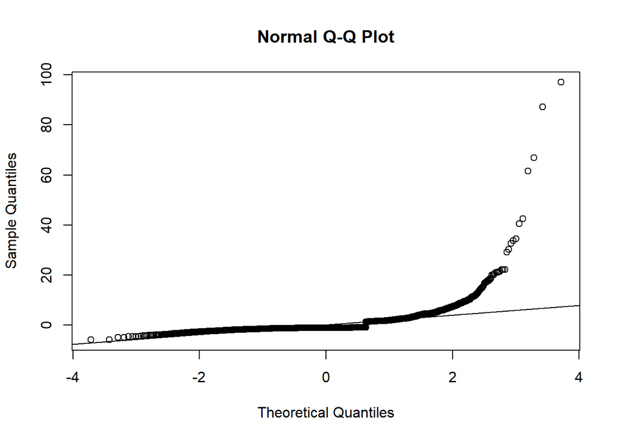

```r
# Q-Q plot for normality
qqnorm(res_3.2)
qqline(res_3.2)
```